# PyTorch实现TPU版本CNN模型

我们将在`Google Colab`中实现执行，因为它提供免费的云`TPU`（张量处理单元）。

验证`TPU`下面的代码是否正常运行。

```python
import os
assert os.environ['COLAB_TPU_ADDR']
```

如果启用了`TPU`，它将成功执行，否则它将返回‘KeyError: ‘COLAB_TPU_ADDR’’。你也可以通过打印`TPU`地址来检查`TPU`。

```python
TPU_Path = 'grpc://'+os.environ['COLAB_TPU_ADDR']
print('TPU Address:', TPU_Path)
```

```
TPU Address: grpc://10.44.255.10:8470
```

启用`TPU`后，我们将安装兼容的控制盘和依赖项，以使用以下代码设置`XLA`环境。

```python
VERSION = "20200516"
!curl https://raw.githubusercontent.com/pytorch/xla/master/contrib/scripts/env-setup.py -o pytorch-xla-env-setup.py
!python pytorch-xla-env-setup.py --version $VERSION
```

[output not shown]

一旦安装成功，我们将继续定义加载数据集、初始化`CNN`模型、训练和测试的方法。首先，我们将导入所需的库。

```python
import numpy as np
import os
import time
import torch
import torch.nn as nn
import torch.nn.functional as F
import torch.optim as optim
import torch_xla
import torch_xla.core.xla_model as xm
import torch_xla.debug.metrics as met
import torch_xla.distributed.parallel_loader as pl
import torch_xla.distributed.xla_multiprocessing as xmp
import torch_xla.utils.utils as xu
from torchvision import datasets, transforms
```

之后，我们将进一步定义需要的超参数。

```python
# 定义参数
FLAGS = {}
FLAGS['datadir'] = "/tmp/mnist"
FLAGS['batch_size'] = 128
FLAGS['num_workers'] = 4
FLAGS['learning_rate'] = 0.01
FLAGS['momentum'] = 0.5
FLAGS['num_epochs'] = 50
FLAGS['num_cores'] = 8
FLAGS['log_steps'] = 20
FLAGS['metrics_debug'] = False
```

下面的代码片段将把`CNN`模型定义为`PyTorch`实例，以及用于加载数据、训练模型和测试模型的函数。

```python
SERIAL_EXEC = xmp.MpSerialExecutor()

class FashionMNIST(nn.Module):

  def __init__(self):
    super(FashionMNIST, self).__init__()
    self.conv1 = nn.Conv2d(1, 10, kernel_size=5)
    self.bn1 = nn.BatchNorm2d(10)
    self.conv2 = nn.Conv2d(10, 20, kernel_size=5)
    self.bn2 = nn.BatchNorm2d(20)
    self.fc1 = nn.Linear(320, 50)
    self.fc2 = nn.Linear(50, 10)

  def forward(self, x):
    x = F.relu(F.max_pool2d(self.conv1(x), 2))
    x = self.bn1(x)
    x = F.relu(F.max_pool2d(self.conv2(x), 2))
    x = self.bn2(x)
    x = torch.flatten(x, 1)
    x = F.relu(self.fc1(x))
    x = self.fc2(x)
    return F.log_softmax(x, dim=1)

# 只在内存中实例化一次模型权重。
WRAPPED_MODEL = xmp.MpModelWrapper(FashionMNIST())

def train_mnist():
  torch.manual_seed(1)

  def get_dataset():
    norm = transforms.Normalize((0.1307,), (0.3081,))
    train_dataset = datasets.FashionMNIST(
        FLAGS['datadir'],
        train=True,
        download=True,
        transform=transforms.Compose(
            [transforms.ToTensor(), norm]))
    test_dataset = datasets.FashionMNIST(
        FLAGS['datadir'],
        train=False,
        download=True,
        transform=transforms.Compose(
            [transforms.ToTensor(), norm]))


    return train_dataset, test_dataset


  #使用串行执行器可以避免多个进程下载相同的数据
  train_dataset, test_dataset = SERIAL_EXEC.run(get_dataset)

  train_sampler = torch.utils.data.distributed.DistributedSampler(
    train_dataset,
    num_replicas=xm.xrt_world_size(),
    rank=xm.get_ordinal(),
    shuffle=True)

  train_loader = torch.utils.data.DataLoader(
      train_dataset,
      batch_size=FLAGS['batch_size'],
      sampler=train_sampler,
      num_workers=FLAGS['num_workers'],
      drop_last=True)

  test_loader = torch.utils.data.DataLoader(
      test_dataset,
      batch_size=FLAGS['batch_size'],
      shuffle=False,
      num_workers=FLAGS['num_workers'],
      drop_last=True)

  # 调整学习率
  lr = FLAGS['learning_rate'] * xm.xrt_world_size()

  # 获取损失函数、优化器和模型
  device = xm.xla_device()
  model = WRAPPED_MODEL.to(device)
  optimizer = optim.SGD(model.parameters(), lr=lr, momentum=FLAGS['momentum'])
  loss_fn = nn.NLLLoss()

  def train_fun(loader):
    tracker = xm.RateTracker()
    model.train()
    for x, (data, target) in enumerate(loader):
      optimizer.zero_grad()
      output = model(data)
      loss = loss_fn(output, target)
      loss.backward()
      xm.optimizer_step(optimizer)
      tracker.add(FLAGS['batch_size'])
      if x % FLAGS['log_steps'] == 0:
        print('[xla:{}]({}) Loss={:.5f}'.format(
            xm.get_ordinal(), x, loss.item(), time.asctime()), flush=True)

  def test_fun(loader):
    total_samples = 0
    correct = 0
    model.eval()
    data, pred, target = None, None, None
    for data, target in loader:
      output = model(data)
      pred = output.max(1, keepdim=True)[1]
      correct += pred.eq(target.view_as(pred)).sum().item()
      total_samples += data.size()[0]

    accuracy = 100.0 * correct / total_samples
    print('[xla:{}] Accuracy={:.2f}%'.format(
        xm.get_ordinal(), accuracy), flush=True)
    return accuracy, data, pred, target

  # 训练和评估循环
  accuracy = 0.0
  data, pred, target = None, None, None
  for epoch in range(1, FLAGS['num_epochs'] + 1):
    para_loader = pl.ParallelLoader(train_loader, [device])
    train_fun(para_loader.per_device_loader(device))
    xm.master_print("Finished training epoch {}".format(epoch))

    para_loader = pl.ParallelLoader(test_loader, [device])
    accuracy, data, pred, target  = test_fun(para_loader.per_device_loader(device))
    if FLAGS['metrics_debug']:
      xm.master_print(met.metrics_report(), flush=True)

  return accuracy, data, pred, target
```

现在，要将结果绘制为测试图像的预测标签和实际标签，将使用以下功能模块。

```python
# 结果可视化
import math
from matplotlib import pyplot as plt

M, N = 5, 5
RESULT_IMG_PATH = '/tmp/test_result.png'

def plot_results(images, labels, preds):
  images, labels, preds = images[:M*N], labels[:M*N], preds[:M*N]
  inv_norm = transforms.Normalize((-0.1307/0.3081,), (1/0.3081,))

  num_images = images.shape[0]
  fig, axes = plt.subplots(M, N, figsize=(12, 12))
  fig.suptitle('Predicted Lables')

  for i, ax in enumerate(fig.axes):
    ax.axis('off')
    if i >= num_images:
      continue
    img, label, prediction = images[i], labels[i], preds[i]
    img = inv_norm(img)
    img = img.squeeze() # [1,Y,X] -> [Y,X]
    label, prediction = label.item(), prediction.item()
    if label == prediction:
      ax.set_title(u'Actual {}/ Predicted {}'.format(label, prediction), color='blue')
    else:
      ax.set_title(
          'Actual {}/ Predicted {}'.format(label, prediction), color='red')
    ax.imshow(img)
  plt.savefig(RESULT_IMG_PATH, transparent=True)
```

```python
# 启动训练流程
def train_cnn(rank, flags):
  global FLAGS
  FLAGS = flags
  torch.set_default_tensor_type('torch.FloatTensor')
  accuracy, data, pred, target = train_mnist()
  if rank == 0:
    # 检索TPU核心0上的张量并绘制。
    plot_results(data.cpu(), pred.cpu(), target.cpu())

xmp.spawn(train_cnn, args=(FLAGS,), nprocs=FLAGS['num_cores'],
          start_method='fork')
```

```
Downloading http://fashion-mnist.s3-website.eu-central-1.amazonaws.com/train-images-idx3-ubyte.gz to /tmp/mnist/FashionMNIST/raw/train-images-idx3-ubyte.gz
```

```
Extracting /tmp/mnist/FashionMNIST/raw/train-images-idx3-ubyte.gz to /tmp/mnist/FashionMNIST/raw
Downloading http://fashion-mnist.s3-website.eu-central-1.amazonaws.com/train-labels-idx1-ubyte.gz to /tmp/mnist/FashionMNIST/raw/train-labels-idx1-ubyte.gz
```

```
Extracting /tmp/mnist/FashionMNIST/raw/train-labels-idx1-ubyte.gz to /tmp/mnist/FashionMNIST/raw
Downloading http://fashion-mnist.s3-website.eu-central-1.amazonaws.com/t10k-images-idx3-ubyte.gz to /tmp/mnist/FashionMNIST/raw/t10k-images-idx3-ubyte.gz
```

```
Extracting /tmp/mnist/FashionMNIST/raw/t10k-images-idx3-ubyte.gz to /tmp/mnist/FashionMNIST/raw
Downloading http://fashion-mnist.s3-website.eu-central-1.amazonaws.com/t10k-labels-idx1-ubyte.gz to /tmp/mnist/FashionMNIST/raw/t10k-labels-idx1-ubyte.gz
```

```
Extracting /tmp/mnist/FashionMNIST/raw/t10k-labels-idx1-ubyte.gz to /tmp/mnist/FashionMNIST/raw
Processing...
```

```
Done!
[xla:7](0) Loss=2.34379
[xla:2](0) Loss=2.33170
[xla:0](0) Loss=2.37092
[xla:1](0) Loss=2.35339
[xla:6](0) Loss=2.35780
[xla:5](0) Loss=2.34328
[xla:4](0) Loss=2.29547
[xla:3](0) Loss=2.37044
[xla:5](20) Loss=0.73221
[xla:3](20) Loss=0.74670
[xla:0](20) Loss=0.66424
[xla:2](20) Loss=0.58707
[xla:7](20) Loss=0.68355
[xla:6](20) Loss=0.65144
[xla:4](20) Loss=0.71517
[xla:1](20) Loss=0.65635
[xla:6](40) Loss=0.65808
[xla:4](40) Loss=0.51412
[xla:0](40) Loss=0.56880
[xla:7](40) Loss=0.43033
[xla:5](40) Loss=0.53017
[xla:1](40) Loss=0.42814
[xla:2](40) Loss=0.53532
[xla:3](40) Loss=0.58242
Finished training epoch 1
[xla:3] Accuracy=82.68%
[xla:1] Accuracy=82.53%
[xla:6] Accuracy=82.65%
[xla:4] Accuracy=82.62%
[xla:2] Accuracy=82.61%
[xla:5] Accuracy=82.67%
[xla:7] Accuracy=82.61%
[xla:0] Accuracy=82.67%
[xla:1](0) Loss=0.47091
[xla:3](0) Loss=0.40922
[xla:6](0) Loss=0.52998
[xla:2](0) Loss=0.47438
[xla:4](0) Loss=0.56421
[xla:5](0) Loss=0.49587
```

[output cut: 1596 more lines]

```
[xla:6](40) Loss=0.14444
[xla:7](40) Loss=0.08155
[xla:1](40) Loss=0.10002
[xla:2](40) Loss=0.13862
[xla:4](40) Loss=0.11087
[xla:3](40) Loss=0.14817
Finished training epoch 50
[xla:4] Accuracy=89.49%
[xla:1] Accuracy=89.58%
[xla:6] Accuracy=89.56%
[xla:3] Accuracy=89.60%
[xla:5] Accuracy=89.54%
[xla:2] Accuracy=89.61%
[xla:7] Accuracy=89.60%
[xla:0] Accuracy=89.60%
```

```python
# 如果想查看时间也可以打印下，不过前面代码并未添加strat_time()，记得添加一下~
# end_time = time.time()
# print('Total Training time = ',end_time-start_time )
```

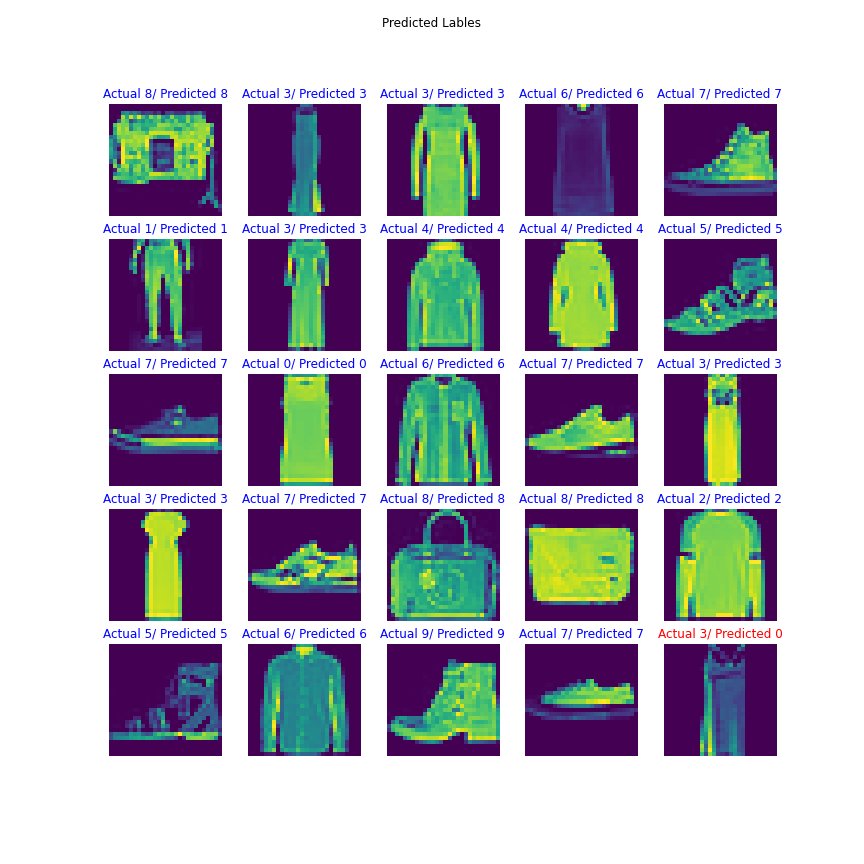

```python
from google.colab.patches import cv2_imshow
import cv2
img = cv2.imread(RESULT_IMG_PATH, cv2.IMREAD_UNCHANGED)
cv2_imshow(img)
```